# LIFE_followup_summary

This is a summary of LIFE Followup assessment (dating to beginning of March 2019).

# MRI sample characteristics

|  | # participants |
| --- | --- |
| invited for mri | 336 |
| received mri | 227 |
| excluded | 109 |
| tinnitus | 3 |
| lense | 2 |
| metal | 16 |
| operation | 15 |
| stents | 9 |
| artifical hips | 5 |
| pacemaker | 3 |
| retainer | 3 |
| claustrophobia | 7 |
| tattoo | 3 |
| unknown | 11 |
| other | 32 |

## Quality of the resting-state fMRI

Physiological measures were acquired with a breathing belt and pulse oximetry. Preprocessing was done with the Physio Toolbox in Matlab (see [links](https://github.com/fBeyer89/life_followup_preproc/blob/master/physio_preprocessing/run_physio_preproc_without_matlab.m) and [links](https://www.tnu.ethz.ch/en/software/tapas/documentations/physio-toolbox.html)). A rough check for completeness of physiological recordings was checked based on file size. See script [links](https://github.com/fBeyer89/life_followup_preproc/blob/master/physio_preprocessing/check_filesize_physio_data.sh)

Physiological parameters extracted with the Physio Toolbox were the resampled respiratory and PPU traces (raw recordings downsampled to fMRI resolution), heart and cardiac phase and heart rate (HR) and respiratory volume per time (RVT)

|  | # participants |
| --- | --- |
| scanned on 26.2.19 | 246 |
| usable physio | 218 |
| missing files | 14 |
| resp error | 1 |
| pulse error | 10 |
| both erroneous | 3 |

Head motion was assessed with mean and maximal framewise displacement based on motion parameters from MCFLIRT. Previous and current methods to calculate mean FD agree:

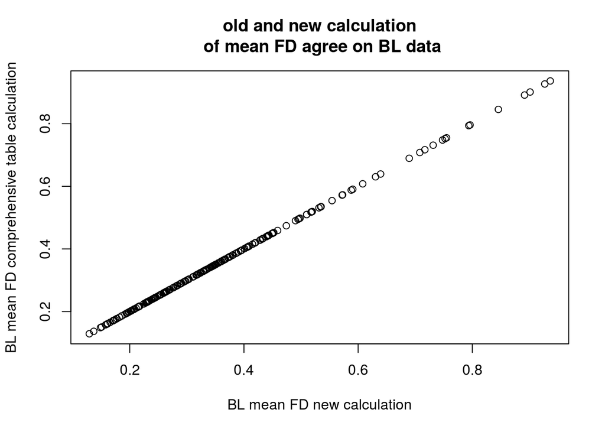

Investigate the association of motion parameters and physio parameters in the followup (N= 239)

Histogram of motion parameters and DVARS

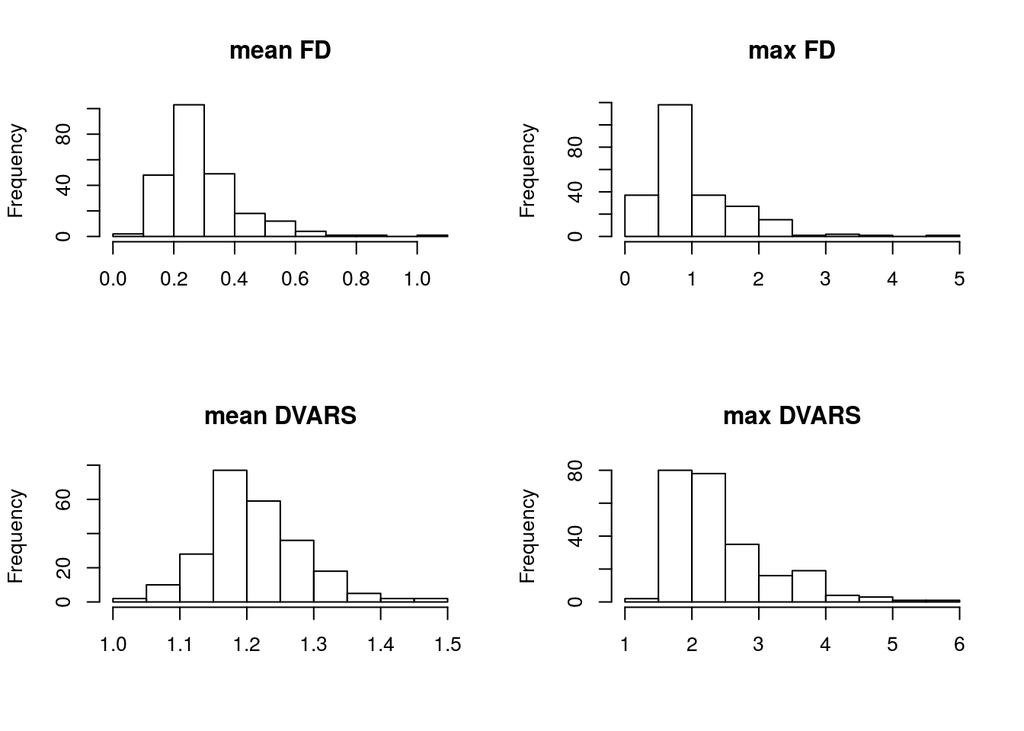

Strong correlation of mean FD and DVARS

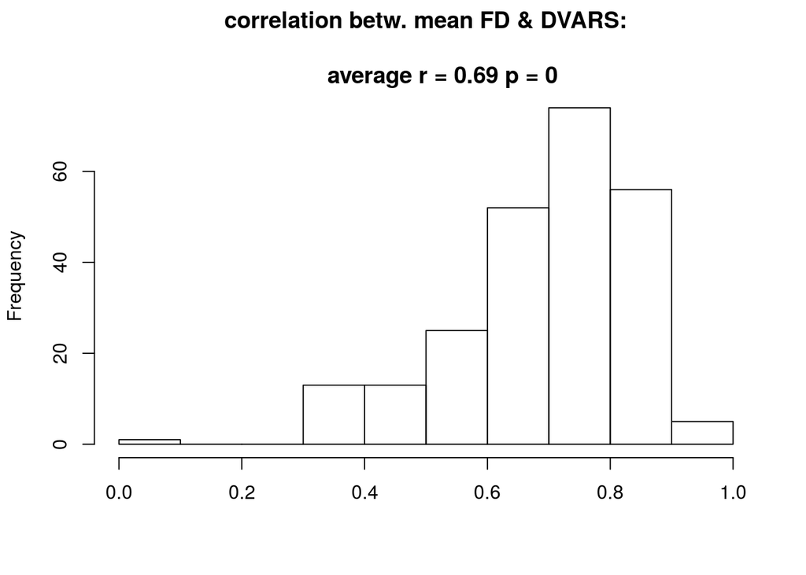

Low/no correlation of motion/DVARS and downsampled resp./PPI traces

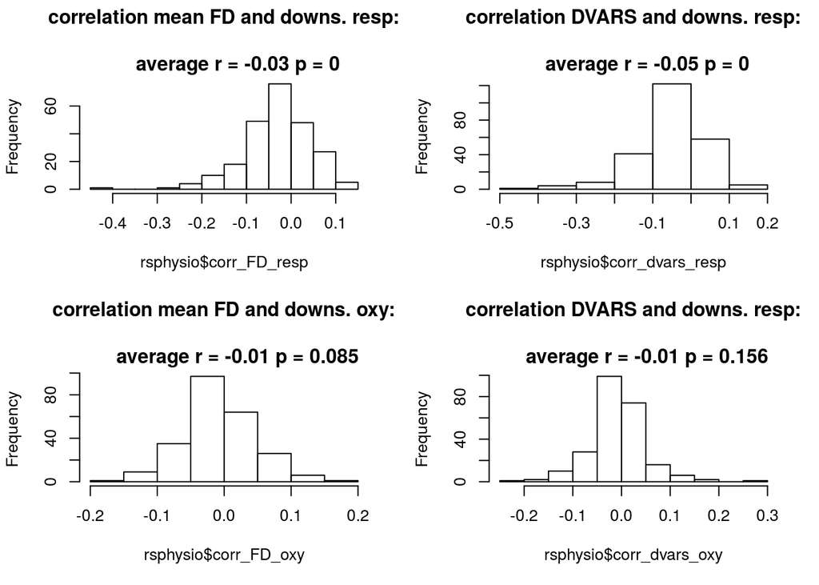

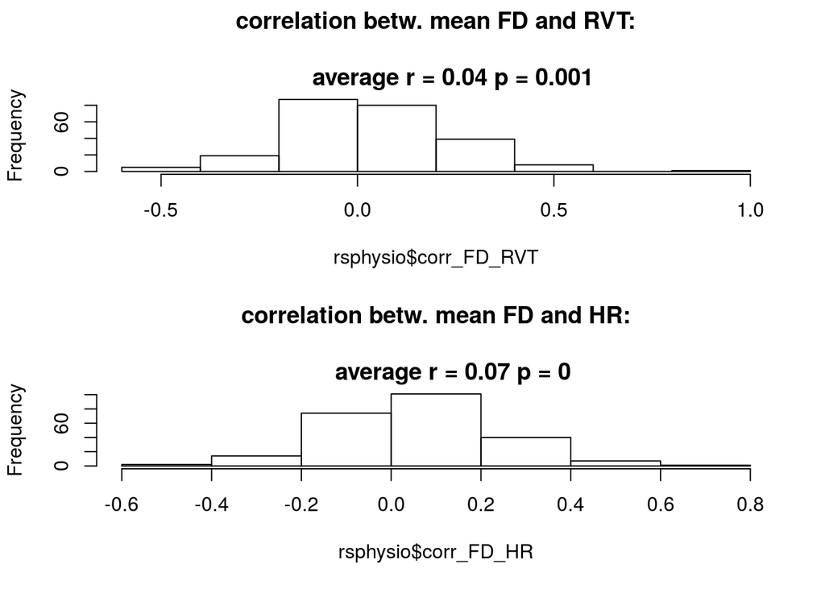

Low/moderate correlation of DVARS and derived physiological parameters RVT and HR

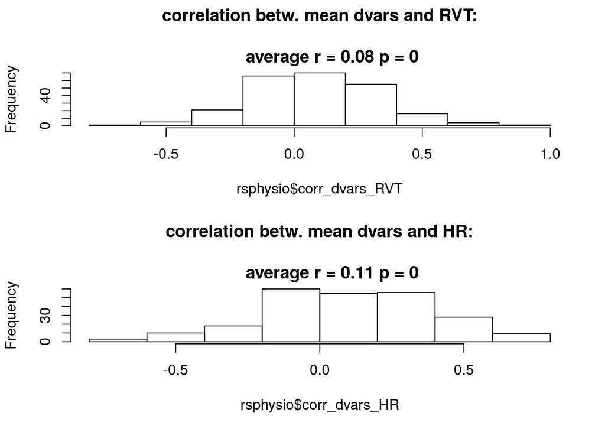

So differences in heart rate and respiratory volume explain only small amount of variance in motion and BOLD fluctuations. Yet, head motion and BOLD fluctuations are strongly associated.

Still, the impact of physiological parameters might be stronger in high motion subjects. There are 20 participants with mean FD > 0.5 mm or max FD > 3mm in the followup sample. 189 have a mean FD > 0.2 mm.

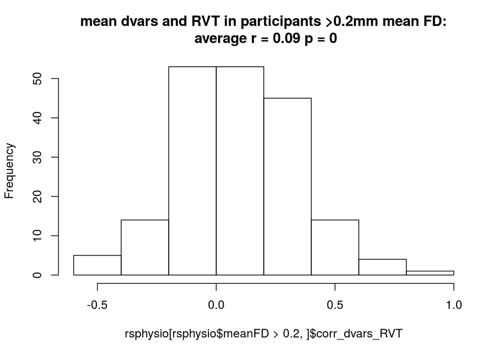

The association of RVT and DVARS is not more pronounced in participants who move more. (Here it was hypothesized that they would breathe possibly more heavily)